# OCLab assembly instruction

Dimitri Fichou

04 April, 2018

## Usefull ressources

3D printing:

- [Reprap project](http://reprap.org/wiki/RepRap)
- [Gcode listing](http://reprap.org/wiki/G-code)
- [Course on 3D printing](https://www.coursera.org/learn/3d-printing-revolution)

Information on each electronic board used:

- [Ramps board](http://reprap.org/wiki/Ramps) (electronic of our machines)
- [Inkshield board for inkjet](http://nicholasclewis.com/projects/inkshield/theory/), more info from people who used the board [here](http://www.instructables.com/id/DIY-BioPrinter/), [here](http://garyhodgson.com/reprap/2012/04/inkshield-trying-to-run-before-i-can-walk/), [here](https://github.com/sjkelly/AMRI-Rice-201308-sjkelly). [Place to buy the cartridge](https://www.ebay.com/itm/Lot-of-200-Empty-Virgin-HP-C6602-Black-Ink-Cartridges-/151788284399)
- [Raspberry pi project](https://www.raspberrypi.org/)
- [Arduino project](https://www.arduino.cc/) (see [those courses](https://www.coursera.org/specializations/iot) for an introduction on the Internet of things)

Some software you will need to install:

- [Openscad software](https://cubehero.com/2013/11/19/know-only-10-things-to-be-dangerous-in-openscad/) (for drawing, see [this tutorial](https://cubehero.com/2013/11/19/know-only-10-things-to-be-dangerous-in-openscad/))
- [Slic3r software](https://github.com/prusa3d/Slic3r/releases) (to create Gcode file for 3d printing, [here is the main page](http://slic3r.org/) but it’s better to install the Prusa edition)
- [Arduino IDE](https://www.arduino.cc/en/Main/Software) (to modify and upload the [marlin firmware](http://marlinfw.org/))

## Part inventory

Bill of material

| Name | Amount/comment | Seller |
| --- | --- | --- |
| Plastic PLA | 1kg | Colorfabb |
| lm8uu bearing | 8 | Motedis |
| lm8uu housing | 4 | Motedis |
| 623zz bearing | 4 | Motedis |
| gt2 belt | 3 | Motedis |
| gt2 pulley 20 teeths | 2 | Motedis |
| Nema 17 | 1 | emotiontech |
| Nema 14 | 1 | emotiontech |
| 8mm stainless steel rod | 4x255 mm | Motedis |
| 20x20 profile 5 I-type | 4x215 mm (X) + 2x255 mm (Y) + 2x120 mm (Y) + 4x 210 mm (Z) | Motedis |
| nut for 20x20 profile 5 I_type | pack of 100 | Motedis |
| cube connector for 20x20 profile | pack of 10 | Motedis |
| angle connector for 20x20 profile | 200 mm is enough | Motedis |
| Screw M5 x 10 | NA | local workshop |
| Screw M5 x 16 | NA | local workshop |
| Screw M3 x 30 | NA | local workshop |
| Screw M3 x 10 | NA | local workshop |
| Screw M3 x 16 | NA | local workshop |
| Screw M4 x 20 | NA | local workshop |
| nut M3 | NA | local workshop |
| nut M4 | NA | local workshop |
| nut M5 | NA | local workshop |
| washer M3 | NA | local workshop |
| washer M4 | NA | local workshop |
| washer M5 | NA | local workshop |
| Glass plates | 1 mm thick, recycled from commercial plates | NA |
| raspberry pi | 1 | Conrad |
| 5v 2.5 A power supplu | 1 | NA |
| 16 Giga bit sd card | 1 | Conrad |
| ethernet cable | 1 | local workshop |
| raspebrry pi camera | 1 | Conrad |
| raspberry pi camera longer cable | 200 mm is enough | Conrad |
| arduino megga 2560 | 1 | Conrad |
| Ramp 1.4 | 1 | amazon |
| A9688 motor driver | 2 | amazon |
| endstop | 2 | amazon |
| Inkshield board | 1 | nerdcreationlab |
| 12v 10A power supply | 5A could be enough | amazon |

## Frame

Needed parts:

- M5 nuts
- 20x20 profiles
- 20x20 cube connectors
- 20x20 angle connectors

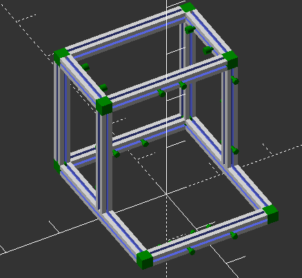

Frame assembly.

## Y axis

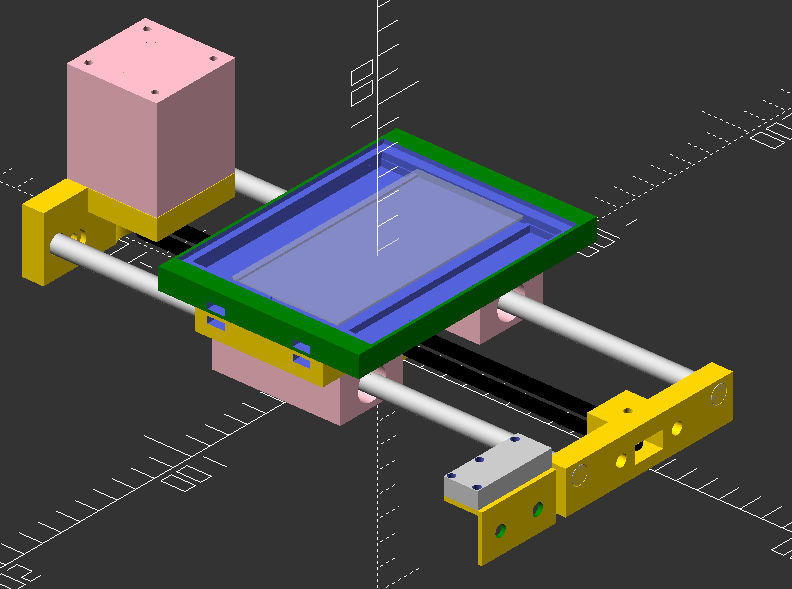

Y axis.

## X axis

Needed parts:

- 2x 8mm rods
- 4x lm8uu bearing
- 2x 623zz bearing
- 1x endstop
- 1x nema14
- 1 meter gt2 belt
- 1x gt2 pulley
- printed parts

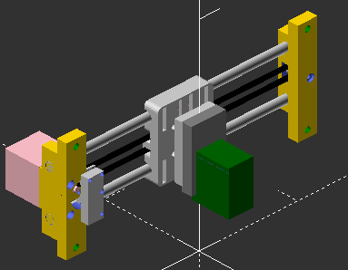

X axis.